# Code 1: Inidividual Radiocarbon Calibration and Correction

Bryan Rodriguez

2026-03-25

*Disclaimer: This code was designed by Bryan Rodriguez-Colon with the help of chatGPT-5.*

# Code 1: Radiocarbon Calibration and Age Conversion

### Overview

This script performs radiocarbon calibration for sediment cores LPC2 and LPC3 using the `IntCal` package. Individual radiocarbon ages are calibrated using appropriate calibration curves depending on material type, and summary statistics (median, mean, and 95% HPD ranges) are extracted for each sample.

### Workflow

1. Load radiocarbon dataset and subset by core (LPC2 and LPC3)
2. Apply material-specific calibration:
   - IntCal20 for terrestrial samples (Plant/Wood, Peat)
   - Marine20 with ΔR = 137 ± 20 years for sediment organic carbon
3. Compute posterior statistics:
   - Median calibrated age (cal BP)
   - Mean calibrated age (cal BP)
   - 95% highest posterior density (HPD) range
4. Convert calibrated ages to calendar years (CE/BCE)
5. Export calibrated datasets for each core

### Calibration Approach

Radiocarbon calibration is performed using `IntCal::calibrate()`.  
Material-specific calibration curves are applied based on sample type to account for differences in carbon reservoirs. Marine samples include a regional reservoir correction (ΔR).

### Output

- `CalibratedDataC2_DeltaR137.csv`
- `CalibratedDataC3_DeltaR137.csv`

Each file contains calibrated ages (cal BP), 95% uncertainty ranges, and calendar year equivalents.

### Visualization

Calibration plots were generated directly using the `IntCal` plotting function and saved manually to ensure consistency with standard calibration curve presentation.

### Reference

Reimer, P.J., et al. (2020). The IntCal20 Northern Hemisphere radiocarbon age calibration curve (0–55 cal kBP). *Radiocarbon*, 62, 725–757.

```r
knitr::opts_chunk$set(echo = TRUE)

rm(list = ls())
#setwd('/Users/bryanrodriguez/Library/Mobile Documents/com~apple~CloudDocs/PhD-PROJECT/R-codes/PRGeobio_XR_C14_StableIsotopes_Codes/RadioCarbon_Codes')
```

```r
library(IntCal)   # radiocarbon calibration
library(dplyr)    # data manipulation
library(tidyr)    # unnest_wider
```

# Functions

## function: `CalOne()`

Calibrate a single radiocarbon date and summarize the posterior

Core calibration function: Uses IntCal::calibrate() to generate posterior distributions and extracts median, mean, and 95% HPD intervals (cal BP)

description: Wrapper around `IntCal::calibrate()` that returns **posterior median, posterior mean, and the overall 95% HPD range** (union of HPD segments), all in **calendar years BP (cal BP)**. Works for IntCal20 (terrestrial) and Marine20 (with optional regional reservoir correction ΔR ± σ).

@param age Numeric. Conventional radiocarbon age (years BP), e.g. 2030. @param err Numeric. 1σ measurement uncertainty of the radiocarbon age, e.g. 15. @param cc Integer. Calibration curve: - `1` = IntCal20 (terrestrial), - `2` = Marine20, - `3` = SHCal20 (southern hemisphere) [supported by `IntCal::calibrate()`].

@param reservoir Numeric. Regional reservoir correction ΔR (years) for marine (or 0 for none). Ignored if `cc != 2`. @param res.err Numeric. 1σ uncertainty of ΔR (years). Ignored if `cc != 2`. @param prob Numeric in (0,1). Credible mass for HPD; default `0.95` (2σ).

@details - The function computes **mean/median from the full calibrated pdf** (not from a single HPD slice), which avoids bias near calibration-curve wiggles or multi-modal posteriors.

- The HPD returned is the **union envelope**: the minimum of all segment starts and the maximum of all segment ends. If you need each HPD segment separately, use `IntCal::calibrate(...)[[2]]` directly.
- Output is always in **cal BP**.

@section Dependencies: Requires `IntCal` package (uses `IntCal::calibrate()`).

@examples Terrestrial (IntCal20): 1000 ± 15 14C BP CalOne(age = 1000, err = 15, cc = 1)

Marine (Marine20) with ΔR = 137 ± 20 CalOne(age = 2030, err = 15, cc = 2, reservoir = 137, res.err = 20)

```r
# To stop images from being created after calling calibrate(), optional.
calibrate_noplot <- function(...){
  grDevices::pdf(NULL)                     # open a null device (no file created)
  on.exit(try(grDevices::dev.off(), silent = TRUE), add = TRUE)
  IntCal::calibrate(...)
}



CalOne <- function(age, err, cc, reservoir = 0, res.err = 0, prob = 0.95){
  res  <- IntCal::calibrate(age = age, error = err, cc = cc, reservoir = reservoir, resError = res.err, prob = prob)
  #res  <- calibrate_noplot(age = age, error = err, cc = cc, reservoir = reservoir, resError = res.err, prob = prob)


  # Density table -> posterior weights
  dens <- as.data.frame(res[[1]])
  names(dens) <- c("calBP","post")
  dens$post <- pmax(dens$post, 0)
  dens <- stats::aggregate(post ~ calBP, data = dens, sum)  # collapse duplicates
  w <- dens$post / sum(dens$post)

  # Mean & median from the full posterior
  mean_cal <- sum(dens$calBP * w)
  cw <- cumsum(w)
  median_cal <- dens$calBP[which(cw >= 0.5)[1]]

  # HPD union (min/max across all segments)
  hpd <- as.data.frame(res[[2]])
  names(hpd)[1:2] <- c("from","to")
  hpd_low  <- min(pmin(hpd$from, hpd$to))
  hpd_high <- max(pmax(hpd$from, hpd$to))

  list(median = as.numeric(median_cal),
       mean   = as.numeric(mean_cal),
       hpd95_low  = as.numeric(hpd_low),
       hpd95_high = as.numeric(hpd_high))
}
```

## function: `summarize_row()`

Select calibration curve and perform radiocarbon calibration for a single sample

description: Wrapper function that assigns the appropriate radiocarbon calibration curve based on material type and applies `CalOne()` to compute posterior summary statistics (median, mean, and 95% HPD range in cal BP).

@param type Character. Material type of the sample (e.g., “Plant/Wood”, “Peat”, or “Sediment Organic carbon”). @param age Numeric. Conventional radiocarbon age (years BP). @param err Numeric. 1σ uncertainty of the radiocarbon age. @param dR Numeric. Regional marine reservoir correction ΔR (years). Default is 137. @param dR_sd Numeric. 1σ uncertainty of ΔR (years). Default is 20.

@return A named list with: \describe{ {median}{Posterior median calibrated age (cal BP).} {mean}{Posterior mean calibrated age (cal BP).} {hpd95_low}{Lower bound of the 95% HPD range (cal BP).}

{hpd95_high}{Upper bound of the 95% HPD range (cal BP).} }

@details - Terrestrial samples (“Plant/Wood”, “Peat”) are calibrated using IntCal20 (`cc = 1`). - Sediment organic carbon samples are calibrated using Marine20 (`cc = 2`) with a regional reservoir correction (ΔR ± σ). - This function ensures consistent application of calibration curves across the dataset.

@section Dependencies: Requires `CalOne()` and `IntCal` package.

@examples summarize_row(“Plant/Wood”, age = 1000, err = 15)

summarize_row(“Sediment Organic carbon”, age = 2030, err = 15, dR = 137, dR_sd = 20)

```r
# --- Row-wise wrapper to pick the right curve/ΔR ----------------------------
summarize_row <- function(type, age, err, dR = 137, dR_sd = 20){
  if(type %in% c("Plant/Wood","Peat")){
    CalOne(age, err, cc = 1)
  } else if(type == "Sediment Organic carbon"){
    CalOne(age, err, cc = 2, reservoir = dR, res.err = dR_sd)
  } else {
    stop(paste("Unknown Type:", type))
  }
}
```

## function: `bp_to_year_ce()` and `fmt_ce_bce()`

Convert calibrated ages (cal BP) to calendar year notation (CE/BCE)

description: Helper functions to convert calibrated radiocarbon ages (cal BP) into calendar years expressed as CE (Common Era) or BCE (Before Common Era).

@param bp Numeric. Calibrated age in years before present (cal BP, where present = 1950 CE). @param year_ce Numeric. Calendar year in CE format.

@return - `bp_to_year_ce()`: Numeric value representing calendar year (CE scale). - `fmt_ce_bce()`: Character string formatted as “XXXX CE” or “XXXX BCE”.

@details - Conversion follows the standard definition:

$$\text{Year (CE)} = 1950 - \text{cal BP}$$

- BCE years are adjusted to account for the absence of year zero in the Gregorian calendar.

@section Notes: These functions are used to provide human-readable calendar ages for reporting and interpretation.

@examples bp_to_year_ce(1000) # returns 950 CE fmt_ce_bce(950) # returns “950 CE” fmt_ce_bce(-500) # returns “501 BCE”

```r
# --- helper to convert cal BP → CE/BCE labels ---
bp_to_year_ce   <- function(bp) 1950 - bp
fmt_ce_bce      <- function(year_ce) ifelse(year_ce >= 1,
                                            sprintf("%d CE", round(year_ce)),
                                            sprintf("%d BCE", abs(round(year_ce - 1))))
```

# Load Sediment Core data.

```r
C14RawData <- read.csv("InputData/Raw_Radiocarbon_Data.csv")

#Data by sediment core.
C2_Data <- subset(C14RawData, Core == "C2")
C3_Data <- subset(C14RawData, Core == "C3")

#Change the Integer classes to numeric classes
IntergerColumns <- c("Depth", "Age", "Age_Err")
C2_Data <- C2_Data %>% mutate_if(names(.) %in% IntergerColumns, as.numeric)
C3_Data <- C3_Data %>% mutate_if(names(.) %in% IntergerColumns, as.numeric)

#Sort the data in numeric order based on the depth column
C2_Data <- C2_Data %>% arrange(C2_Data$Depth)
C3_Data <- C3_Data %>% arrange(C3_Data$Depth)
```

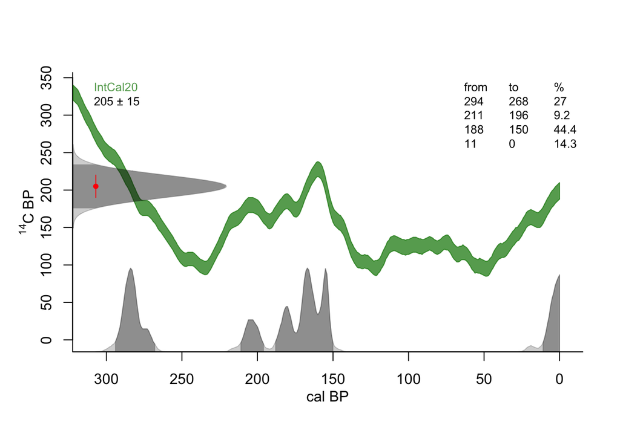

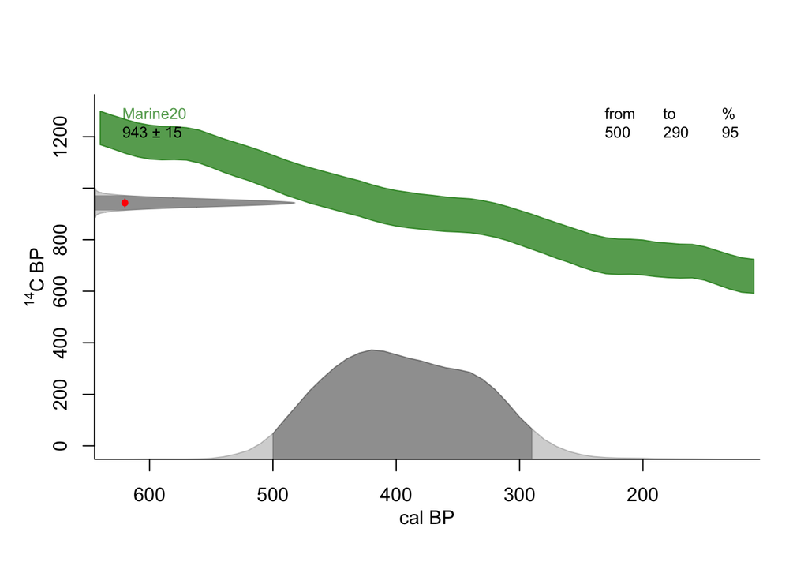

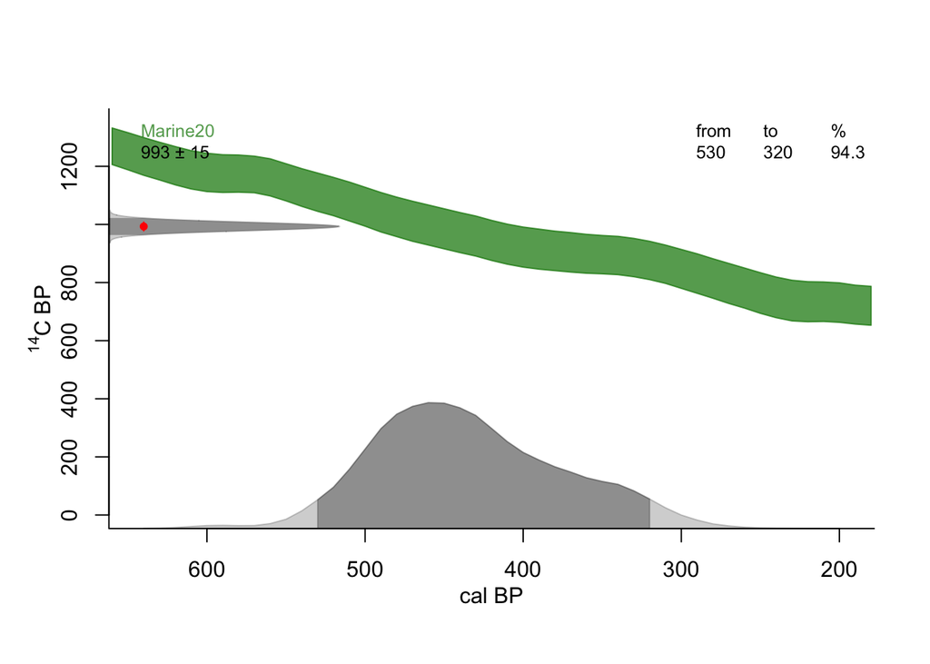

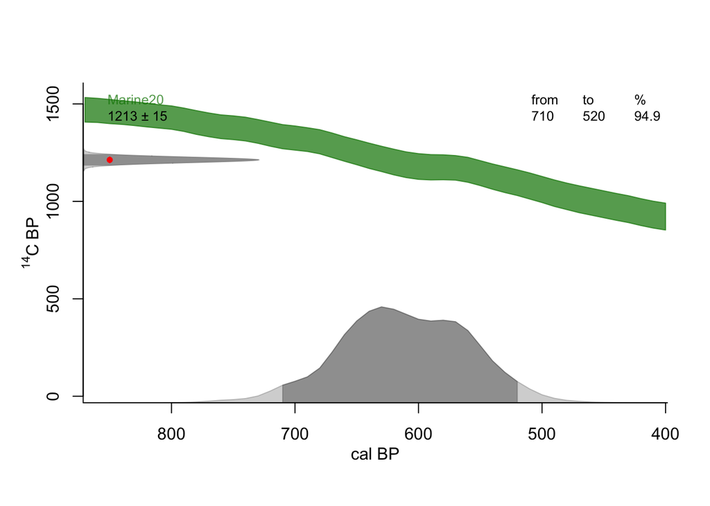

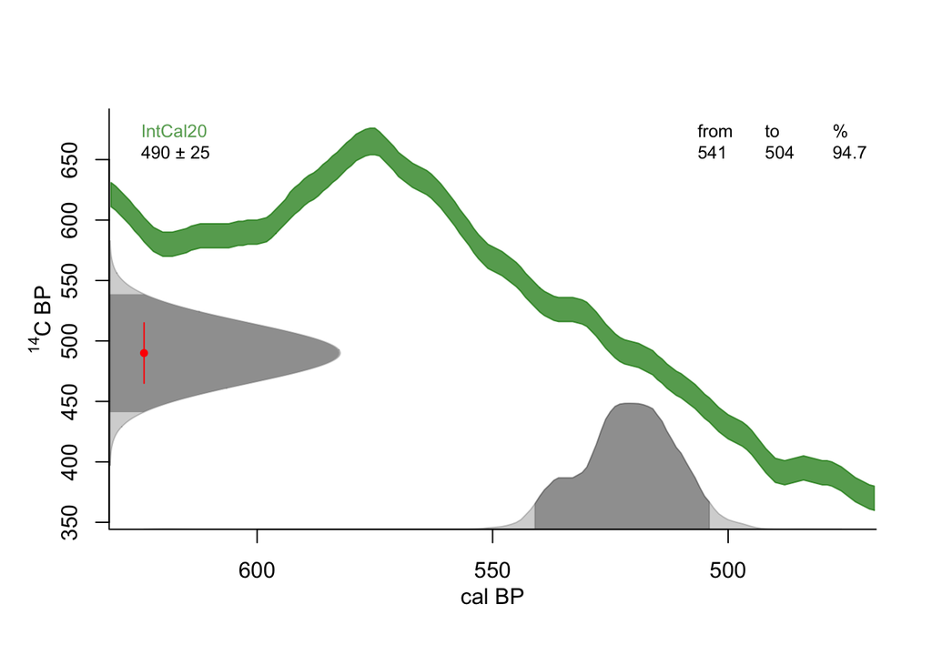

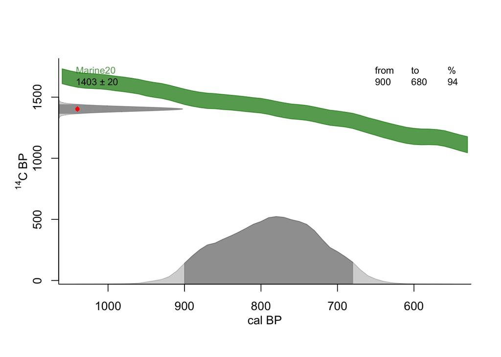

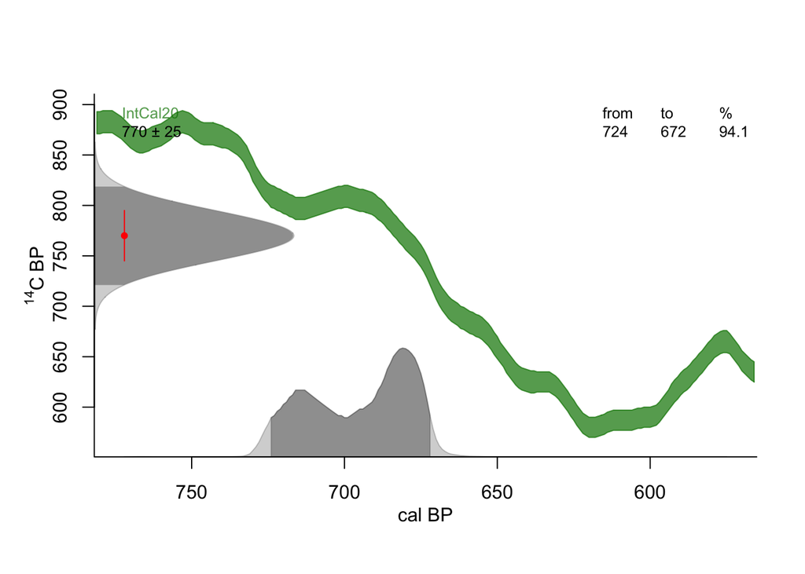

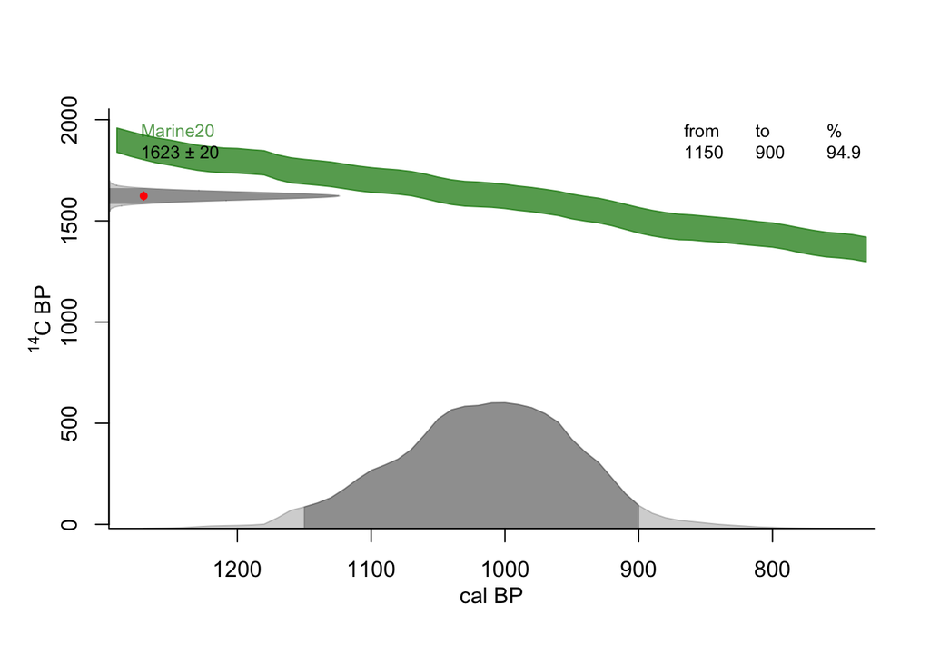

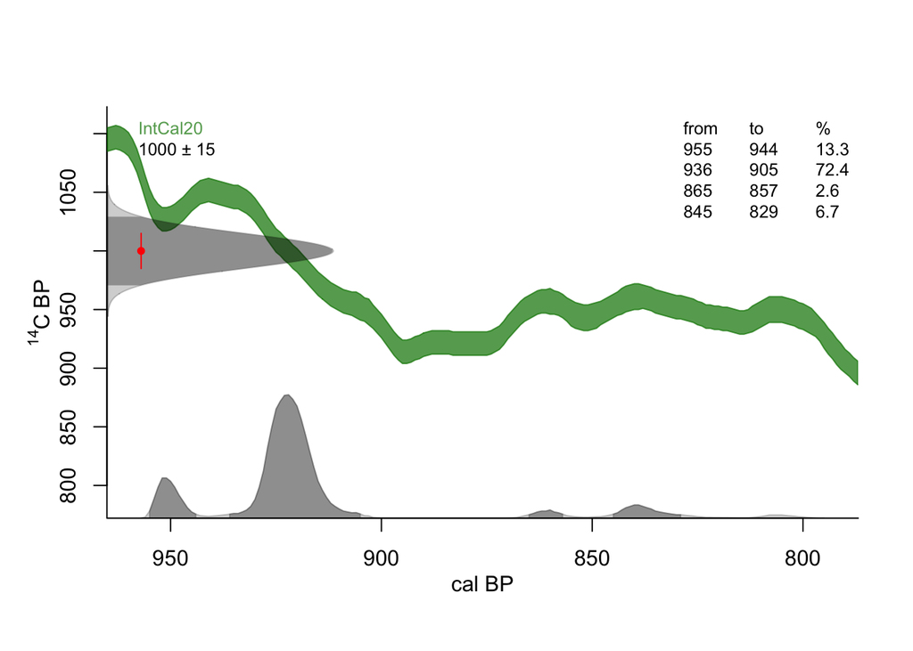

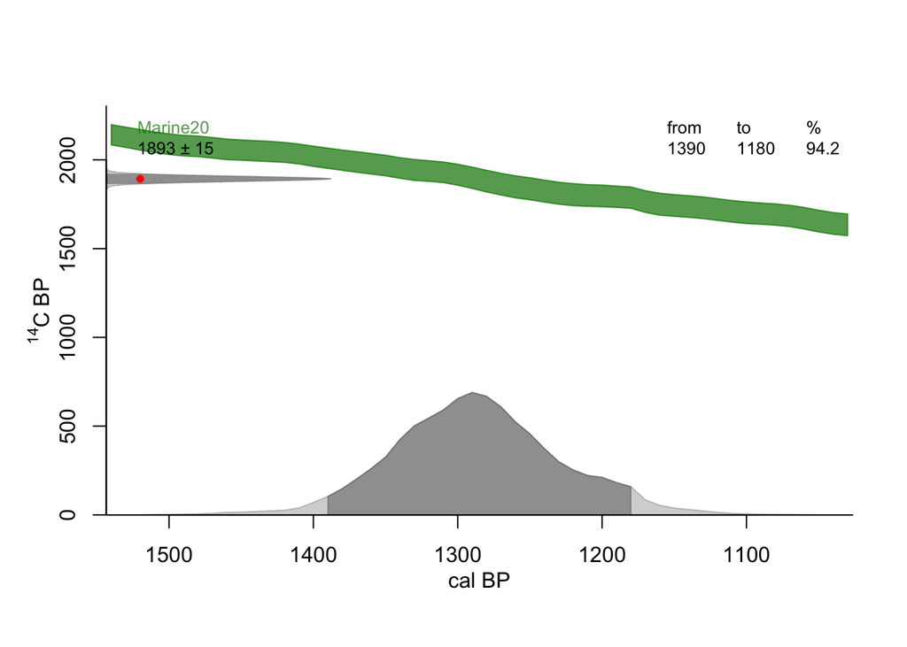

```r
# --- C2 summary with CE/BCE fields (individual calibrations) ---
C2_clean <- C2_Data %>%
  arrange(Depth) %>%
  rowwise() %>%
  mutate(cal = list(summarize_row(Type, Age, Age_Err))) %>%
  ungroup() %>%
  tidyr::unnest_wider(col = cal) %>%
  mutate(
    Curve = dplyr::case_when(
      Type %in% c("Plant/Wood","Peat") ~ "IntCal20",
      Type == "Sediment Organic carbon" ~ "Marine20 (ΔR=137±20)"
    ),
    # rounded manuscript-friendly numbers
    cal_median = round(median),
    cal95_low  = round(hpd95_low),
    cal95_high = round(hpd95_high),
    cal_mean   = round(mean),
    Calibrated_95_range = sprintf("%d–%d", cal95_low, cal95_high),
    #Label_median_95HPD  = sprintf("%d [%d–%d]", cal_median, cal95_low, cal95_high),

    # CE/BCE conversions
    year_ce_median = bp_to_year_ce(cal_median),
    year_ce_min95  = bp_to_year_ce(cal95_high),  # (older BP → smaller CE)
    year_ce_max95  = bp_to_year_ce(cal95_low),
    label_median_cal = fmt_ce_bce(year_ce_median)
  ) %>%
  select(Core, Depth, Type, Age, Age_Err, Curve,
         cal_median, cal95_low, cal95_high, cal_mean,
         Calibrated_95_range,
         year_ce_median, year_ce_min95, year_ce_max95, label_median_cal)
```

```r
write.csv(C2_clean, "OutputData/CalibratedDataC2_DeltaR137.csv", row.names = FALSE)
```

## LPC3 core

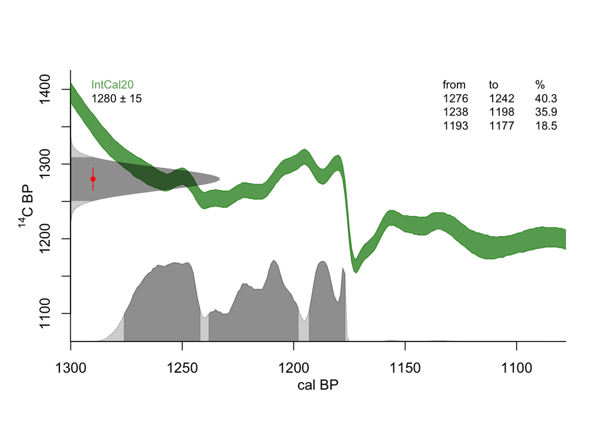

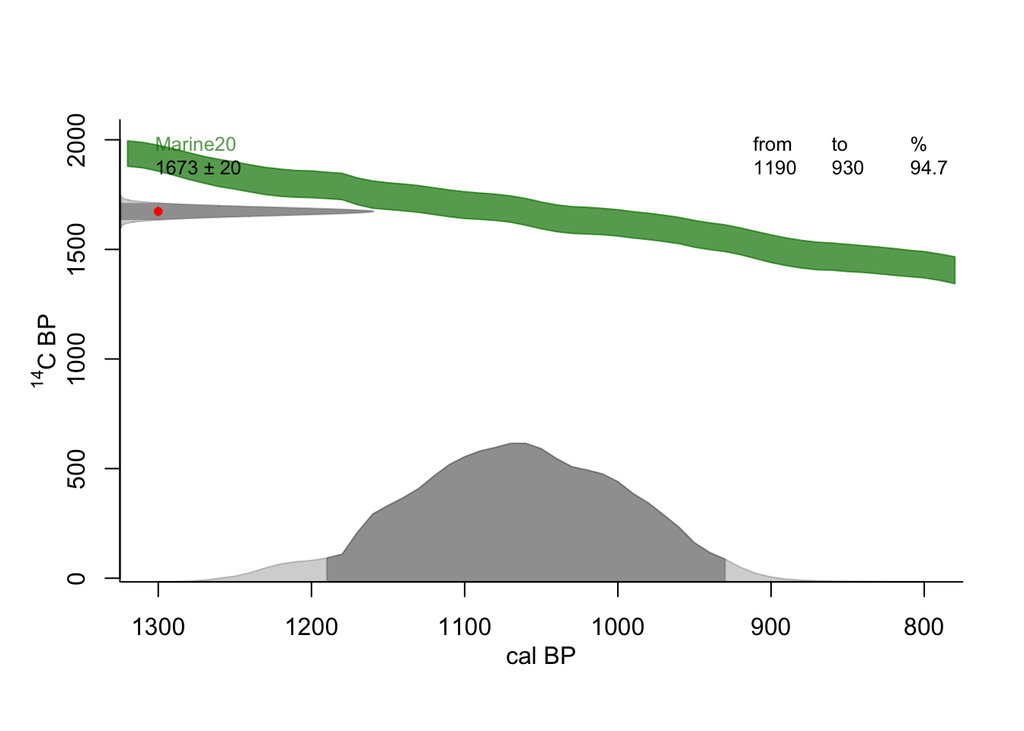

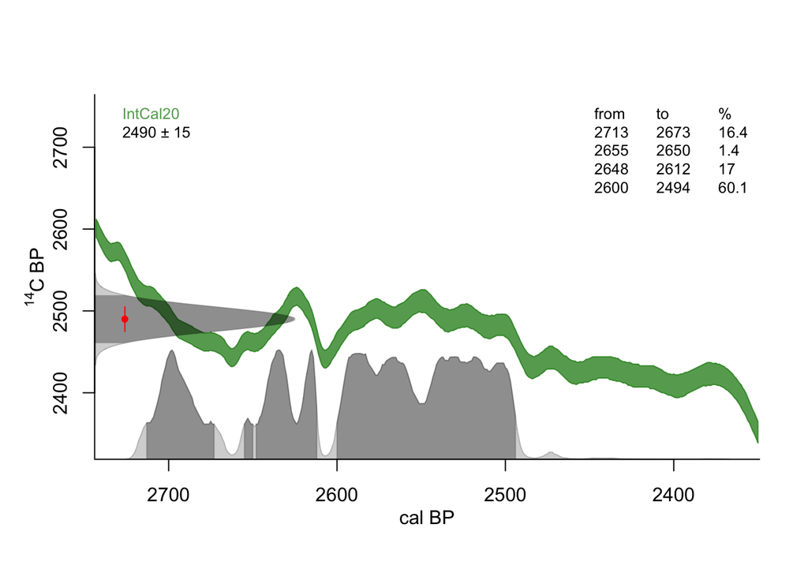

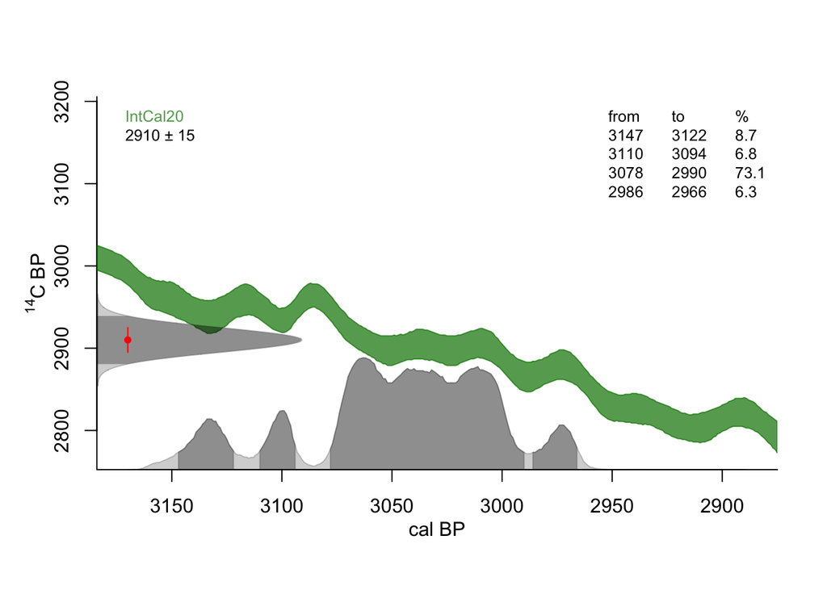

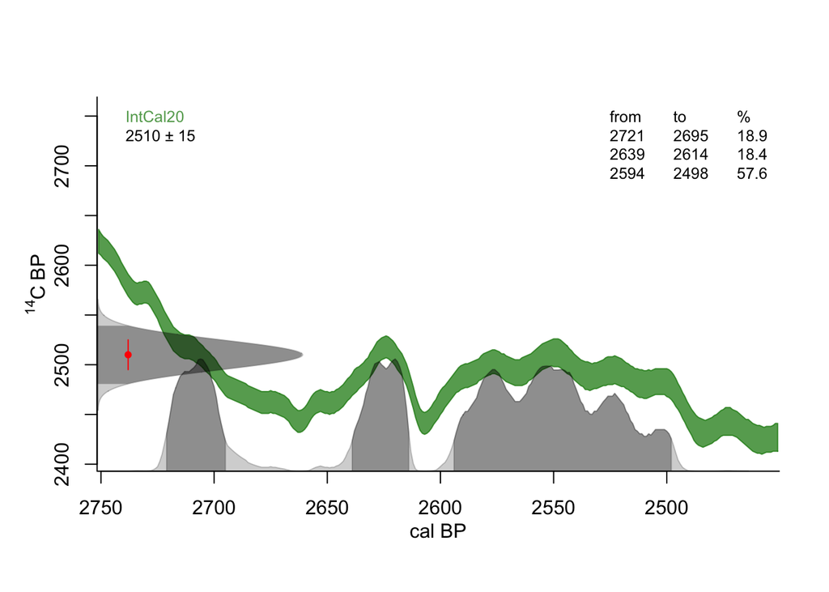

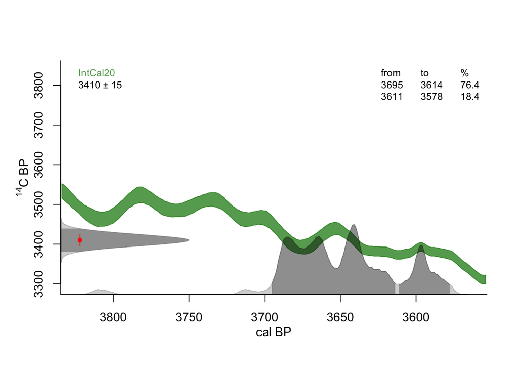

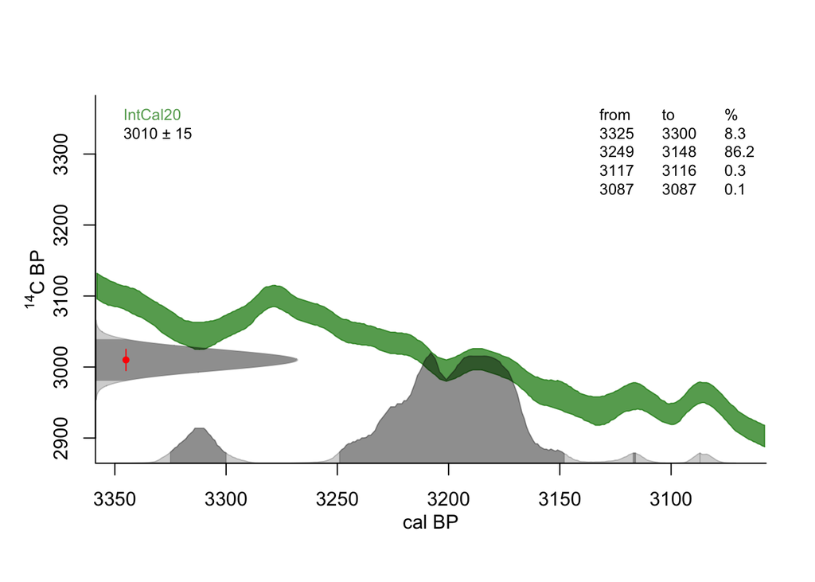

```r
C3_clean <- C3_Data %>%
  arrange(Depth) %>%
  rowwise() %>%
  mutate(cal = list(summarize_row(Type, Age, Age_Err))) %>%
  ungroup() %>%
  tidyr::unnest_wider(col = cal) %>%
  mutate(
    Curve = dplyr::case_when(
      Type %in% c("Plant/Wood","Peat") ~ "IntCal20",
      Type == "Sediment Organic carbon" ~ "Marine20 (ΔR=137±20)"
    ),
    cal_median = round(median),
    cal95_low  = round(hpd95_low),
    cal95_high = round(hpd95_high),
    cal_mean   = round(mean),
    Calibrated_95_range = sprintf("%d–%d", cal95_low, cal95_high),
    #Label_median_95HPD  = sprintf("%d [%d–%d]", cal_median, cal95_low, cal95_high),

    year_ce_median = bp_to_year_ce(cal_median),
    year_ce_min95  = bp_to_year_ce(cal95_high),
    year_ce_max95  = bp_to_year_ce(cal95_low),
    label_median_cal = fmt_ce_bce(year_ce_median)
  ) %>%
  select(Core, Depth, Type, Age, Age_Err, Curve,
         cal_median, cal95_low, cal95_high, cal_mean,
         Calibrated_95_range,
         year_ce_median, year_ce_min95, year_ce_max95, label_median_cal)
```

```r
write.csv(C3_clean, "OutputData/CalibratedDataC3_DeltaR137.csv", row.names = FALSE)
```